# Ein 3D-CNN für Ziffern-Volumen — trainieren und erklären

[output not shown]

[output not shown]

[output not shown]

[output not shown]

[output not shown]

[output not shown]

[output not shown]

[output not shown]

[output not shown]

[output not shown]

[output not shown]

[output not shown]

[output not shown]

[output not shown]

[output not shown]

[output not shown]

[output not shown]

[output not shown]

[output not shown]

[output not shown]

[output not shown]

[output not shown]

[output not shown]

[output not shown]

[output not shown]

[output not shown]

[output not shown]

[output not shown]

[output not shown]

[output not shown]

[output not shown]

[output not shown]

[output not shown]

[output not shown]

[output not shown]

[output not shown]

```
313/313 ━━━━━━━━━━━━━━━━━━━━ 2s 8ms/step - accuracy: 0.9358 - loss: 0.3699 - val_accuracy: 0.8305 - val_loss: 1.1279 - learning_rate: 1.0000e-04
```

[output not shown]

[output not shown]

[output not shown]

[output not shown]

[output not shown]

[output not shown]

[output not shown]

[output not shown]

[output not shown]

[output not shown]

[output not shown]

[output not shown]

[output not shown]

[output not shown]

[output not shown]

[output not shown]

[output not shown]

[output not shown]

[output not shown]

[output not shown]

[output not shown]

[output not shown]

[output not shown]

[output not shown]

[output not shown]

[output not shown]

[output not shown]

[output not shown]

[output not shown]

[output not shown]

[output not shown]

[output not shown]

[output not shown]

[output not shown]

[output not shown]

[output not shown]

[output not shown]

[output not shown]

[output not shown]

[output not shown]

```
313/313 ━━━━━━━━━━━━━━━━━━━━ 2s 8ms/step - accuracy: 0.9373 - loss: 0.3649 - val_accuracy: 0.8350 - val_loss: 1.1468 - learning_rate: 1.0000e-04
```

[output not shown]

[output not shown]

[output not shown]

[output not shown]

[output not shown]

[output not shown]

[output not shown]

[output not shown]

[output not shown]

[output not shown]

[output not shown]

[output not shown]

[output not shown]

[output not shown]

[output not shown]

[output not shown]

[output not shown]

[output not shown]

[output not shown]

[output not shown]

[output not shown]

[output not shown]

[output not shown]

[output not shown]

[output not shown]

[output not shown]

[output not shown]

[output not shown]

[output not shown]

[output not shown]

[output not shown]

[output not shown]

[output not shown]

[output not shown]

[output not shown]

[output not shown]

[output not shown]

[output not shown]

[output not shown]

[output not shown]

[output not shown]

[output not shown]

```
313/313 ━━━━━━━━━━━━━━━━━━━━ 2s 8ms/step - accuracy: 0.9341 - loss: 0.3695 - val_accuracy: 0.8335 - val_loss: 1.1169 - learning_rate: 1.0000e-04
```

[output not shown]

[output not shown]

[output not shown]

[output not shown]

[output not shown]

[output not shown]

[output not shown]

[output not shown]

[output not shown]

[output not shown]

[output not shown]

[output not shown]

[output not shown]

[output not shown]

[output not shown]

[output not shown]

[output not shown]

[output not shown]

[output not shown]

[output not shown]

[output not shown]

[output not shown]

[output not shown]

[output not shown]

[output not shown]

[output not shown]

[output not shown]

[output not shown]

[output not shown]

[output not shown]

[output not shown]

[output not shown]

[output not shown]

[output not shown]

[output not shown]

[output not shown]

[output not shown]

[output not shown]

[output not shown]

[output not shown]

[output not shown]

```
313/313 ━━━━━━━━━━━━━━━━━━━━ 2s 8ms/step - accuracy: 0.9387 - loss: 0.3652 - val_accuracy: 0.8330 - val_loss: 1.1544 - learning_rate: 1.0000e-04
```

[output not shown]

[output not shown]

[output not shown]

[output not shown]

[output not shown]

[output not shown]

[output not shown]

[output not shown]

[output not shown]

[output not shown]

[output not shown]

[output not shown]

[output not shown]

[output not shown]

[output not shown]

[output not shown]

[output not shown]

[output not shown]

[output not shown]

[output not shown]

[output not shown]

[output not shown]

[output not shown]

[output not shown]

[output not shown]

[output not shown]

[output not shown]

[output not shown]

[output not shown]

[output not shown]

[output not shown]

[output not shown]

[output not shown]

[output not shown]

[output not shown]

[output not shown]

[output not shown]

[output not shown]

[output not shown]

[output not shown]

[output not shown]

```
313/313 ━━━━━━━━━━━━━━━━━━━━ 2s 8ms/step - accuracy: 0.9361 - loss: 0.3665 - val_accuracy: 0.8220 - val_loss: 1.1868 - learning_rate: 1.0000e-04
```

[output not shown]

[output not shown]

[output not shown]

[output not shown]

[output not shown]

[output not shown]

[output not shown]

[output not shown]

[output not shown]

[output not shown]

[output not shown]

[output not shown]

[output not shown]

[output not shown]

[output not shown]

[output not shown]

[output not shown]

[output not shown]

[output not shown]

[output not shown]

[output not shown]

[output not shown]

[output not shown]

[output not shown]

[output not shown]

[output not shown]

[output not shown]

[output not shown]

[output not shown]

[output not shown]

[output not shown]

[output not shown]

[output not shown]

[output not shown]

[output not shown]

[output not shown]

[output not shown]

[output not shown]

[output not shown]

[output not shown]

[output not shown]

```
313/313 ━━━━━━━━━━━━━━━━━━━━ 2s 8ms/step - accuracy: 0.9391 - loss: 0.3541 - val_accuracy: 0.8385 - val_loss: 1.0915 - learning_rate: 1.0000e-04
```

```
Model gespeichert unter: /mnt/users/andreasre/git-repos/keras-explainability/output/notebooks/Train_and_explain_3D_mnist_model/100_epochs/3d_mnist_cnn.keras
```

## 6. LRP: zehn Erklärungen für ein Volumen

↑ Inhaltsverzeichnis

Das ist die **Kernzelle des Notebooks**. Hier wird zum ersten Mal nicht gefragt „was sagt das Netz?", sondern „**warum** sagt es das?".

### 6.1 Die Mathematik: wie LRP rückwärts rechnet

Jedes Neuron $k$ berechnet im Vorwärtspass

$$z_k \;=\; \sum_j a_j \, w_{jk} \;+\; b_k$$

LRP dreht das um: Hat Neuron $k$ die Relevanz $R_k$ zugewiesen bekommen, gibt es sie an seine Vorgänger $j$ weiter — **proportional zu deren Beitrag** $a_j w_{jk}$:

$$R_j \;=\; \sum_k \frac{a_j\,w_{jk}}{\sum_{j'} a_{j'} w_{j'k}} \; R_k$$

Der Bruch summiert sich über $j$ zu 1, deshalb gilt die **Erhaltung** $\sum_j R_j = \sum_k R_k$: Relevanz wird nur umverteilt, nie erzeugt. Das ist die **z-Regel** oder **LRP-0**.

Startpunkt der Rückwärtsrechnung ist eine Maske auf der Ausgabeschicht: nur das Neuron der erklärten Klasse behält seinen Wert, alle anderen werden auf 0 gesetzt.

$$R_k^{(\text{letzte Schicht})} \;=\; \begin{cases} z_{\text{idx}} & k = \text{idx} \\ 0 & \text{sonst}\end{cases}$$

**Wichtig:** Verwendet wird der Wert **vor** der Softmax, das sogenannte *Logit*. `LRP` entfernt die Softmax-Aktivierung intern selbst (`remove_activation`). Das ist Absicht — die Softmax normalisiert über alle zehn Klassen, ihr Gradient vermischt sie und macht Erklärungen unschärfer.

### 6.2 Warum nicht überall dieselbe Regel? Die Composite-Strategie

LRP-0 in Reinform rauscht stark: Der Nenner $\sum_{j'} a_{j'} w_{j'k}$ kann fast null werden, wenn sich positive und negative Beiträge aufheben — dann explodiert der Bruch. Über zehn Schichten hinweg multipliziert sich das auf. Deshalb setzt man **pro Schichtbereich eine eigene Regel** ein (*Composite-LRP*, Montavon et al. 2019):

| Regel | Formel | Wirkung |
| --- | --- | --- |
| **LRP-ε** | $R_j = \sum_k \dfrac{a_j w_{jk}}{z_k + \epsilon\,\mathrm{sign}(z_k)} R_k$ | $\epsilon$ dämpft Neuronen mit $\lvert z_k\rvert \approx 0$ gegen null → **Rauschfilter** |
| **LRP-αβ** | $R_j = \sum_k \left(\alpha \dfrac{(a_j w_{jk})^{+}}{z_k^{+}} - \beta \dfrac{(a_j w_{jk})^{-}}{z_k^{-}}\right) R_k$ | trennt Pro- von Contra-Evidenz, sehr stabil |
| **b-Regel** | $a_j \equiv 1$ statt der echten Aktivierung | macht die Verteilung **unabhängig vom Voxelwert** |

Nebenbedingung für αβ: $\alpha - \beta = 1$. Der Code erzwingt das (`assert alpha == beta + 1`) — nur so bleibt die Relevanz erhalten. `alpha=2, beta=1` heißt also: positive Beiträge doppelt gewichten, negative einfach abziehen.

### 6.3 Die Strategie in dieser Zelle

`LRPStrategy(layers=[...])` erwartet **genau einen Eintrag pro gewichtstragender Schicht**. Unser Netz hat 8 `Conv3D` + 2 `Dense` = **10** davon, also 10 Einträge. Die Liste ist **von der Eingabe zur Ausgabe** geordnet (intern wird sie mit `[::-1]` gedreht, weil das Erklärer-Netz rückwärts aufgebaut wird):

| Eintrag | Regel | Schicht | Warum |
| --- | --- | --- | --- |
| 1 | `b=True`, α=1, β=0 | `conv1` | Aktivierungen durch Einsen ersetzen → die Heatmap hängt nicht mehr von der Voxel*helligkeit* ab, sondern nur von der *Lage*. Wirkt wie ein räumlicher Glätter. |
| 2–8 | α=2, β=1 | `conv2`…`conv8` | stabile, kontrastreiche Verteilung durch die Faltungsblöcke |
| 9–10 | ε = 0,25 | `dense`, `preds` | Rauschunterdrückung im Klassifikationskopf, wo sich viele Beiträge gegenseitig aufheben |

Die vier Pooling-Schichten stehen nicht in der Liste. Sie behalten die Voreinstellung *winner-takes-all*: die gesamte Relevanz eines 2×2×2-Fensters geht an das Voxel, das im Vorwärtspass das Maximum lieferte.

### 6.4 Was die Zelle konkret rechnet

```
explainer = LRP(model, layer=len(model.layers)-1, idx=i, strategy=strategy)
explanations[i] = explainer(train_X[654:655])
```

| Argument | Bedeutung |
| --- | --- |
| `model` | das trainierte Netz |
| `layer=33` | ab welcher Schicht rückwärts erklärt wird → `preds` (34 Schichten, Index 0-basiert) |
| `idx=i` | **welches Ausgabeneuron** erklärt wird → Ziffer $i$ |
| `strategy` | die Regelkombination aus 6.3 |

`LRP` ist selbst ein **Keras-Modell**: Der Graph des Originalnetzes wird topologisch sortiert, umgedreht, und jede Schicht durch ihr LRP-Gegenstück ersetzt. Der Aufruf `explainer(...)` ist dann ein ganz normaler Vorwärtspass durch dieses Erklärer-Netz. Rechenaufwand: etwa wie ein Trainingsschritt.

Die Schleife baut **zehn** solcher Erklärer — einen pro Zielklasse. Das Ergebnis ist ein Array `explanations` der Form `(10, 16, 16, 16, 1)`: für jede der zehn Ziffern ein vollständiges Relevanzvolumen. Das ist der entscheidende Punkt, den Anfänger oft übersehen:

> **LRP erklärt nicht „die Vorhersage", sondern immer eine konkret gewählte Klasse.** Man kann auch eine Klasse erklären lassen, die das Netz gar nicht gewählt hat — die Frage lautet dann: „Was sprach für und gegen *diese* Ziffer?"

`image_idx = 654` wählt ein Trainingsbeispiel aus. Es zeigt eine **3**, die etwa 615 der 4096 Voxel belegt (15 %) und in den Schnittebenen 5 bis 10 liegt.

### 6.5 Was die Ausgabe zeigt

[output not shown]

Danach die zehn Relevanzsummen. Stellt man sie den tatsächlichen Logits gegenüber (dem Wert der Ausgabeneuronen vor der Softmax, also genau dem, womit LRP startet), ergibt sich:

[output not shown]

### 6.6 Interpretation — drei Beobachtungen

- **Bias-Terme.** Der Code korrigiert mit `R = (R * z) / (z + bias)`; der Bias-Anteil an der Aktivierung „verschluckt" Relevanz. Bei neun BatchNorm-Schichten, die in die Faltungen hineingerechnet werden, summiert sich das.
- **Die ε-Regel** vergrößert absichtlich den Nenner und verliert dadurch Relevanz.
- **Die αβ-Regel** ist nur bei exakter Kompensation streng erhaltend.

Für die Praxis heißt das: **Relevanzsummen sind eine gute Plausibilitätsprüfung, keine Bilanz.** Weicht die Summe um Größenordnungen vom Logit ab, ist etwas kaputt.

### Einordnung

Ein negativer Logit bedeutet: *„Dieses Volumen spricht insgesamt **gegen** die Ziffer 4."* Die zugehörige Heatmap zeigt also nicht, wo eine 4 wäre, sondern **wo die Evidenz dagegen sitzt**. Anfänger interpretieren solche Karten regelmäßig falsch. Die Faustregel:

> **Vor dem Deuten einer Heatmap immer die Vorhersage und das Vorzeichen des Logits ansehen.**

```python
from explainability import LRP, LRPStrategy


alpha = 2
beta = 1

strategy = LRPStrategy(
    layers=[
        {'b': True, 'alpha': 1, 'beta': 0},
        {'alpha': alpha, 'beta': beta},
        {'alpha': alpha, 'beta': beta},
        {'alpha': alpha, 'beta': beta},
        {'alpha': alpha, 'beta': beta},
        {'alpha': alpha, 'beta': beta},
        {'alpha': alpha, 'beta': beta},
        {'alpha': alpha, 'beta': beta},
        {'epsilon': 0.25},
        {'epsilon': 0.25}
    ]
)

image_idx = 654

explanations = np.zeros((10, 16, 16, 16, 1))
predictions = model.predict(train_X[image_idx:image_idx + 1])
print(f'Predictions: {predictions[0]}')

for i in range(10):
    explainer = LRP(model, layer=len(model.layers)-1, idx=i, strategy=strategy)
    explanations[i] = explainer(train_X[image_idx:image_idx + 1])
    print(f'Sum evidence for {i}: {np.sum(explanations[i])}')
```

```
1/1 ━━━━━━━━━━━━━━━━━━━━ 0s 1s/step
```

```
1/1 ━━━━━━━━━━━━━━━━━━━━ 1s 1s/step
```

```
Predictions: [5.6294064e-16 1.8853186e-10 5.7805711e-09 9.9975580e-01 9.9809414e-09
 2.4402235e-04 9.3748849e-09 1.3877910e-07 9.7803854e-10 5.7913795e-11]
```

```
Sum evidence for 0: -22.335380163214722
```

```
Sum evidence for 1: -8.802234108009543
```

```
Sum evidence for 2: -5.667866178004033
```

```
Sum evidence for 3: 9.455814553844903
```

```
Sum evidence for 4: -4.873613383263518
```

```
Sum evidence for 5: 2.884228918895616
```

```
Sum evidence for 6: -5.654485337511815
```

```
Sum evidence for 7: -3.267887458120157
```

```
Sum evidence for 8: -7.373181610639122
```

```
Sum evidence for 9: -11.569067636442924
```

## 7. Die Slice-Galerie: 10 Klassen × 16 Schichten

↑ Inhaltsverzeichnis

Dies ist die **zentrale Abbildung des Notebooks**. Sie beantwortet die Frage: Wie sieht die Erklärung für jede der zehn Ziffern aus, Schicht für Schicht durch das Volumen?

### 7.1 Was passiert hier?

Die Zelle baut ein Raster mit **20 Zeilen × 16 Spalten**. Je zwei Zeilen bilden einen Block:

```
  Zeile 2i     ── das Original-Volumen, Schnitte 0…15   (immer identisch!)
  Zeile 2i+1   ── die Relevanzkarte für Ziffer i, dieselben Schnitte
```

Die Beschriftung links (`ID i (p)`) nennt die Zielklasse und die vom Netz vergebene Wahrscheinlichkeit.

Vor dem Zeichnen werden die Relevanzen in zwei Schritten aufbereitet:

**1. Normierung auf $[-1, 1]$.**

$$\tilde{R}^{(i)} \;=\; \frac{R^{(i)}}{\max_{xyz} \lvert R^{(i)}_{xyz}\rvert}$$

**2. Nullpunkt-Korrektur.** `explanations[i] -= explanations[i, 0, 0, 0, 0]` zieht den Wert des Eckvoxels ab. Die Annahme dahinter: Diese Ecke ist garantiert leer, ihre Relevanz sollte also 0 sein; was übrig bleibt, ist ein systematischer Offset. In der Praxis liegt dieser Wert bei etwa $10^{-4}$ — die Korrektur ist also **praktisch wirkungslos**, aber als Gedanke sauber.

⚠️ Beide Operationen schreiben **in-place** in `explanations` zurück. Die nächste Zelle (Abschnitt 8) arbeitet deshalb bereits mit den normierten Werten, nicht mehr mit den Rohrelevanzen. Führt man diese Zelle zweimal aus, wird zweimal normiert — beim zweiten Mal ist das wirkungslos, weil das Maximum dann schon 1 ist.

### 7.2 Die beiden Farbskalen

| Zeile | Aufruf | Skala | Bedeutung |
| --- | --- | --- | --- |
| Original | `imshow(...)` ohne `cmap` | `viridis` (Standard) | dunkelviolett = 0 (leer), grün/gelb = belegt |
| Erklärung | `imshow(..., cmap='seismic', clim=(-1,1))` | divergierend | **rot = pro**, **weiß = irrelevant**, **blau = contra** |

Dass die Originalschnitte violett statt weiß erscheinen, ist reine Konvention von `viridis`: Der **leere Raum ist der dunkelviolette Untergrund**. Nur die sechs Schichten mit Ziffer zeigen grün-gelbe Strukturen.

### 7.3 Was man auf der Abbildung sieht

**Die Originalzeilen (jeder zweite Block) sind zehnmal identisch** — es ist immer dasselbe Volumen. Nur in den **Schnitten 5 bis 10** ist etwas zu sehen: eine diagonal im Raum liegende **3**. Die Schnitte 5 und 10 zeigen die **gefüllten Endflächen** (je ~138 Voxel), die Schnitte 6 bis 9 nur noch den **Umriss** (je 85 Voxel) — das Volumen ist innen hohl, wie eine aus der 2D-Ziffer extrudierte Schale.

**Die Erklärungszeilen zerfallen in zwei Gruppen:**

[output not shown]

**Alle zehn Karten zeigen dieselbe räumliche Struktur** — die Kontur der 3. Sie unterscheiden sich im Wesentlichen nur durch das **Vorzeichen** und die Intensität.

**Die Relevanz reicht über die Ziffer hinaus.** Sichtbare Struktur liegt in den Schnitten **3 bis 12**, obwohl die Ziffer nur in 5 bis 10 existiert. Es bekommen also auch **leere Voxel Relevanz** — bei einer Nachrechnung landen rund 47 % der Gesamtrelevanz auf Voxeln mit Wert 0.

### 7.4 Interpretation

**Warum bekommen leere Voxel Relevanz?** Das ist die direkte Folge der **b-Regel** in `conv1` (Abschnitt 6.3): Dort wird $a_j \equiv 1$ gesetzt, die tatsächliche Voxelintensität also ignoriert. Relevanz kann deshalb auf Positionen fließen, die im Input leer sind. Zwei Dinge folgen daraus:

1. **Es ist kein Bug.** Es ist genau der Zweck der Regel — die Karte soll räumlich zusammenhängend sein statt aus Einzelvoxeln zu bestehen.
2. **Es ist trotzdem interessant.** „Hier ist nichts, und genau das spricht für eine 3" ist eine legitime Aussage: Der leere Raum *neben* der Ziffer ist Teil ihrer Form. Man darf solche Bereiche nur nicht als „das Netz schaut auf Rauschen" fehldeuten.

### Einordnung

Genau so liest man auch eine LRP-Karte eines MRT-Volumens: schichtweise durchblättern, die Struktur mit der Anatomie abgleichen, und immer im Kopf behalten, **welche** Klasse gerade erklärt wird. Der Unterschied ist nur, dass man beim Gehirn keine „richtige Antwort" hat, gegen die man die Karte prüfen kann — hier schon.

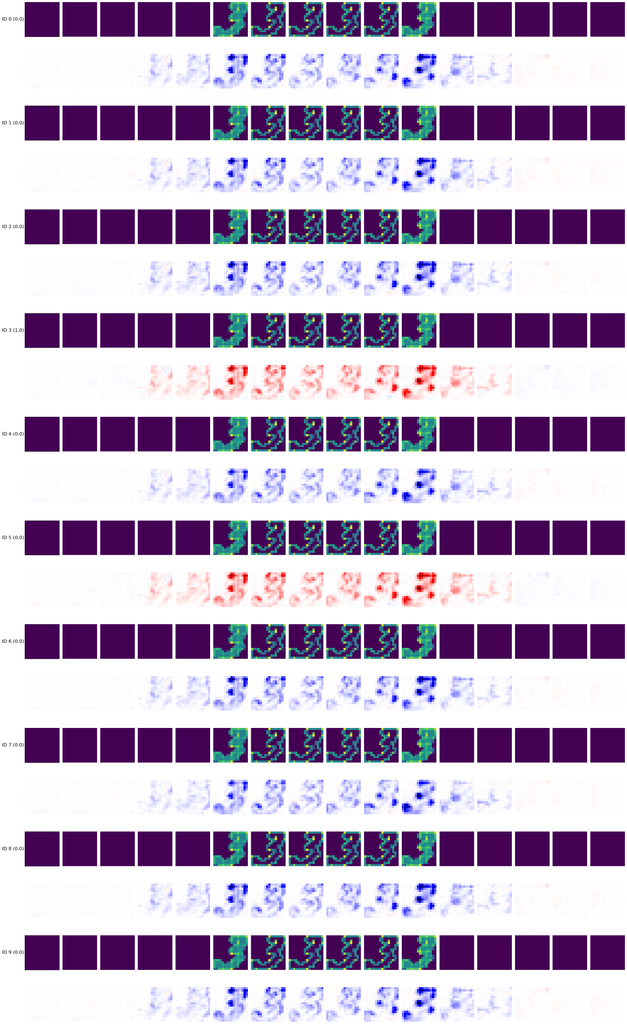

```python
import matplotlib.pyplot as plt
import numpy as np

num_explanations = len(explanations)

# 1. Erstelle EINE große Figur vor der Schleife
# Zeilen = 2 * Anzahl der Erklärungen, Spalten = 16
fig, ax = plt.subplots(2 * num_explanations, 16, figsize=(30, 5 * num_explanations))

for i in range(num_explanations):
    explanations[i] = explanations[i] / np.amax(np.abs(explanations[i]))
    explanations[i] -= explanations[i, 0, 0, 0, 0]

    # Berechne die korrekten Zeilen-Indizes für diese Erklärung
    row_orig = 2 * i
    row_expl = 2 * i + 1

    # Optional: Ein Titel pro Block links am Rand (da suptitle sonst alles überschreibt)
    ax[row_orig][0].set_ylabel(f'ID {i} ({round(predictions[0,i], 2)})',
                               fontsize=16, rotation=0, labelpad=40, va='center')

    for j in range(16):
        # Originalbilder in die obere Zeile des Blocks
        ax[row_orig][j].imshow(train_X[image_idx, :, :, j])
        ax[row_orig][j].set_xticks([])
        ax[row_orig][j].set_yticks([])

        # Erklärungen in die untere Zeile des Blocks
        ax[row_expl][j].imshow(explanations[i, :, :, j], cmap='seismic', clim=(-1, 1))
        ax[row_expl][j].set_xticks([])
        ax[row_expl][j].set_yticks([])

        # Rahmen ausschalten (außer für das erste Bild wegen des Labels links)
        if j > 0:
            ax[row_orig][j].axis('off')
        ax[row_expl][j].axis('off')

# 2. Layout optimieren, damit sich die Zeilen nicht überschneiden
plt.tight_layout()

# 3. Als eine einzige, große Datei speichern
fig.savefig(target_dir / "all_slices_combined.png", bbox_inches='tight', dpi=150)

# 4. Am Ende einmal anzeigen und Speicher freigeben
plt.show()
plt.close(fig)
```

## 8. Die Differenzmatrix: wie klassenspezifisch sind die Erklärungen?

↑ Inhaltsverzeichnis

### 8.1 Was passiert hier?

Ein 10×10-Raster. In Zeile $i$, Spalte $j$ steht die **Differenz** zweier Relevanzkarten, jeweils auf **Schnittebene 5** (mitten durch die Ziffer):

$$D_{ij} \;=\; \tilde{R}^{(i)}_{:,:,5} \;-\; \tilde{R}^{(j)}_{:,:,5}$$

Verwendet werden dabei die **bereits normierten** Karten aus Abschnitt 7 — diese Zelle setzt also voraus, dass die vorherige gelaufen ist. Dieselbe Farbskala: rot = $D_{ij} > 0$ (Klasse $i$ bewertet dieses Voxel positiver), blau = $D_{ij} < 0$, weiß = beide gleich.

**Die Idee dahinter** ist die schärfere Frage: Nicht *„welche Voxel sprechen für die 3?"*, sondern *„welche Voxel unterscheiden eine 3 von einer 8?"*. Das ist der Übergang von einer **absoluten** zu einer **kontrastiven** Erklärung — in der XAI-Literatur die deutlich informativere Variante, weil sie der Frage entspricht, die Menschen tatsächlich stellen („warum das und nicht jenes?").

### 8.2 Was man auf der Abbildung sieht

**Die Diagonale ist weiß.** $D_{ii} = 0$ — eine Karte minus sich selbst. Das ist die Selbstkontrolle: Wäre die Diagonale nicht weiß, wäre der Code fehlerhaft.

**Die Matrix ist antisymmetrisch.** Feld $(i,j)$ ist das exakte Farbnegativ von $(j,i)$, denn $D_{ij} = -D_{ji}$.

### 8.3 Interpretation — der unbequeme Befund

> **Es gibt hier nicht zehn Erklärungen, sondern im Wesentlichen eine — einmal mit Plus, einmal mit Minus davor.**

### 8.4 ⚠️ Grenzen dieser Darstellung

- **Nur eine von 16 Schichten.** `[:,:,5]` zeigt die gefüllte Endfläche der Ziffer. Andere Schnitte könnten anders aussehen; die Zelle prüft das nicht.
- **Differenz normierter Größen.** Weil jede Karte auf ihr eigenes Maximum skaliert wurde, mischt $D_{ij}$ Unterschiede in der *Form* mit Unterschieden im *Maßstab*. Ein Teil des Rot in Zeile 3 ist also nur Normierungseffekt.
- **Keine Achsenbeschriftung.** Man muss wissen, dass Zeile/Spalte $i$ der Ziffer $i$ entspricht.

### Einordnung

Der Befund „alle Klassen erklären sich gleich" ist ein bekanntes Problem und der Grund, warum **Sanity Checks** zum Standardrepertoire gehören. Der berühmteste ist der *Model Parameter Randomization Test* (Adebayo et al., 2018): Man randomisiert die Gewichte schichtweise und schaut, ob sich die Heatmap ändert. Tut sie es nicht, misst die Methode Bildstruktur statt Modellverhalten.

Was man hier praktisch tun würde:

- ein **unsicheres** Beispiel wählen (etwa eines mit 60 : 40 zwischen zwei Ziffern) — dort werden die Unterschiede sichtbar;
- ein Netz **ohne** GlobalAveragePooling gegentesten;
- die Differenz der **Roh**relevanzen statt der normierten betrachten.

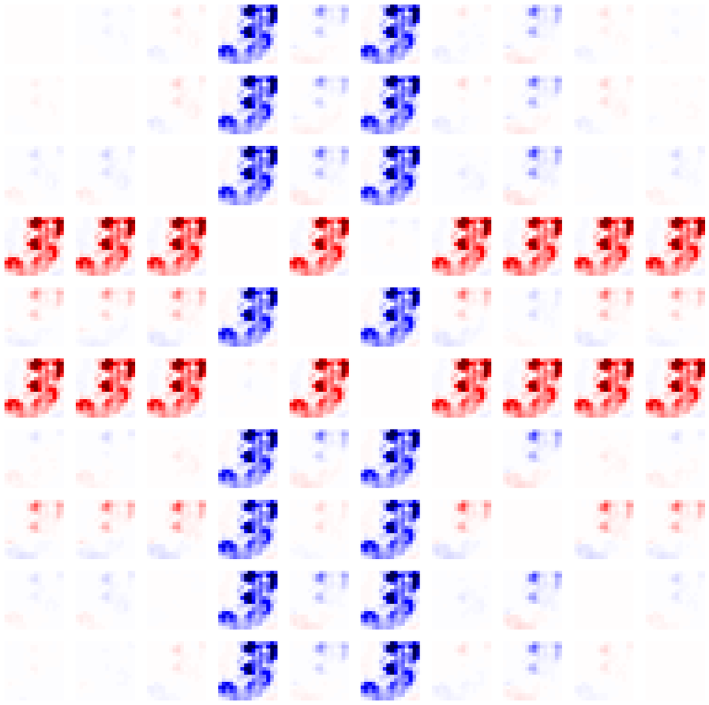

```python
fig, ax = plt.subplots(10, 10, figsize=(20, 20))

for i in range(10):
    for j in range(10):
        ax[i][j].axis('off')
        ax[i][j].imshow(explanations[i,:,:,5] - explanations[j,:,:,5], cmap='seismic', clim=(-1, 1))

plt.show()
```

## 9. Das Volumen als 3D-Punktwolke

↑ Inhaltsverzeichnis

Bis hierher haben wir das Volumen nur **scheibenweise** betrachtet. Ab jetzt schauen wir es als Ganzes an — und zwar interaktiv drehbar.

### 9.1 Was passiert hier?

Die Funktion `plot_digit_3d` macht drei Dinge:

**1. Kanaldimension entfernen.** `vol[..., 0]` macht aus `(16,16,16,1)` ein `(16,16,16)`.

**2. Belegte Voxel finden.**

```
z, y, x = np.where(vol > threshold)
```

`np.where` liefert die **Koordinaten** aller Voxel über dem Schwellwert 0,1 — als drei parallele Index-Arrays. Bei unserem Beispiel sind das **615 von 4096** Voxeln (15 %).

Das ist der entscheidende Trick: Statt 4096 Würfel zu rendern (von denen 85 % unsichtbar leer wären), zeichnet man nur die 615 belegten als Punkte. Diese Umwandlung von einer **dichten Gitterdarstellung** in eine **dünne Punktliste** ist der Standardweg, 3D-Daten im Browser darstellbar zu machen.

**3. Als `Scatter3d` zeichnen.** Jeder Punkt bekommt seine Voxelintensität als Farbe (`colorscale="Viridis"`), `opacity=0.85` macht ihn leicht durchscheinend, damit man auch das Innere sieht. `aspectmode="cube"` erzwingt gleiche Achsenskalierung — ohne das würde Plotly die Achsen an das Fenster anpassen und die Ziffer verzerren.

### 9.2 Was man auf der Abbildung sehen sollte

Eine **frei drehbare Punktwolke** in einem 16×16×16-Würfel: die Ziffer **3**, als flache Schale in den Raum extrudiert und schräg im Würfel liegend. Genau die Struktur, die in Abschnitt 7 als sechs Schnittbilder zu sehen war — nur eben auf einen Blick. Mit der Maus lässt sie sich in die Lage drehen, in der die 3 als Ziffer lesbar wird.

### 9.3 ⚠️ Hinweis zum HTML-Export

**In der exportierten HTML-Datei fehlt diese Abbildung.** Plotly-Grafiken sind JavaScript, kein Bild; beim Export mit `nbconvert` ohne passende Renderer-Einstellung bleibt die Ausgabe leer. Im laufenden Notebook erscheint die Grafik normal.

Wer sie im HTML haben will, setzt vor dem Export

```
import plotly.io as pio
pio.renderers.default = "notebook_connected"   # oder "notebook" für Offline-Einbettung
```

Das ist ein typischer Stolperstein bei geteilten Notebooks: Was man selbst sieht, sieht der Empfänger des HTML-Exports nicht unbedingt.

### 9.4 Der Schwellwert als versteckte Entscheidung

`threshold=0.1` blendet alle Voxel unter 10 % Intensität aus. Bei diesem Datensatz ist das unkritisch — von 616 Voxeln mit Wert > 0 überleben 615, es fällt also genau eines heraus. Bei medizinischen Daten ist die Schwelle dagegen **eine inhaltliche Entscheidung**: Sie bestimmt, was als „Gewebe" gilt und was als Hintergrund. Eine schlecht gewählte Schwelle kann eine ganze Struktur unsichtbar machen. Solche Parameter gehören dokumentiert.

### Einordnung

Dieser Abschnitt leitet den letzten Teil des Notebooks ein: Ab jetzt geht es um **Darstellung**, nicht mehr um Berechnung. Für die Kommunikation von Ergebnissen — an Kliniker, an Gutachter, an das eigene Team — ist eine drehbare 3D-Ansicht oft überzeugender als 16 Schnittbilder, weil sie keine räumliche Vorstellungsleistung verlangt.

```python
import plotly.graph_objects as go

def plot_digit_3d(vol, title="", threshold=0.1):
    vol = np.asarray(vol[..., 0] if vol.ndim == 4 else vol)
    z, y, x = np.where(vol > threshold)
    fig = go.Figure(go.Scatter3d(
        x=x, y=y, z=z, mode="markers",
        marker=dict(size=4, opacity=0.85, color=vol[z, y, x], colorscale="Viridis"),
    ))
    fig.update_layout(
        title=title,
        scene=dict(aspectmode="cube",
                   xaxis=dict(range=[0, 16]), yaxis=dict(range=[0, 16]), zaxis=dict(range=[0, 16])),
        margin=dict(l=0, r=0, t=40, b=0),
    )
    fig.show()

idx = image_idx
plot_digit_3d(train_X[idx], title=f"Label: {np.argmax(train_y[idx])}")
```

## 10. Eine 3D-Zahl rein → Vorhersage raus

↑ Inhaltsverzeichnis

### Was passiert hier?

Die komplette Inferenz-Pipeline in fünf Zeilen — nützlich als Vorlage zum Kopieren:

| Zeile | Was sie tut |
| --- | --- |
| `sample = train_X[idx:idx+1]` | ein Beispiel als **Batch der Größe 1** ausschneiden, Form `(1,16,16,16,1)` |
| `probs = model.predict(sample, verbose=0)[0]` | zehn Wahrscheinlichkeiten; `[0]` holt das erste (einzige) Element des Batches |
| `pred = int(np.argmax(probs))` | Index der größten Wahrscheinlichkeit = vorhergesagte Ziffer |
| `true = int(np.argmax(train_y[idx]))` | One-Hot-Label zurück in eine Zahl übersetzen |

Der **Slice** `idx:idx+1` statt `[idx]` ist kein Schönheitsfehler, sondern notwendig: `train_X[654]` hätte die Form `(16,16,16,1)`, und Keras würde die erste Achse als Batch-Dimension missverstehen. `verbose=0` unterdrückt lediglich den Fortschrittsbalken.

### Ausgabe

[output not shown]

### Interpretation

**Die Vorhersage ist korrekt** — und das ist die Voraussetzung dafür, dass die Erklärungen aus Abschnitt 7 überhaupt interpretierbar sind. Bei einer Fehlklassifikation würde die Heatmap erklären, *warum das Netz sich irrt* — auch spannend, aber eine ganz andere Frage.

### Einordnung

Dieser Abschnitt schließt den Kreis zu Abschnitt 6: Dort wurde dieselbe Vorhersage berechnet, aber als Startwert für LRP. Hier steht sie für sich, als das, was ein Anwender vom Modell tatsächlich zu sehen bekommt. Die eine Zahl („3, mit 99,9 %") ist alles, was ohne XAI übrig bleibt — die nächsten Abschnitte zeigen, was dahintersteckt.

```python
idx = image_idx
sample = train_X[idx:idx + 1]          # Shape (1, 16, 16, 16, 1)
probs = model.predict(sample, verbose=0)[0]
pred = int(np.argmax(probs))
true = int(np.argmax(train_y[idx]))

print(f"True: {true} | Pred: {pred} | Confidence: {probs[pred]:.4f}")
print(probs)
```

```
True: 3 | Pred: 3 | Confidence: 0.9998
[5.6294064e-16 1.8853256e-10 5.7805822e-09 9.9975580e-01 9.9809414e-09
 2.4402235e-04 9.3749035e-09 1.3877923e-07 9.7803854e-10 5.7913906e-11]
```

## 11. Input und Erklärung nebeneinander in 3D

↑ Inhaltsverzeichnis

Der Höhepunkt des Notebooks: Eingabe und Erklärung **in derselben Geometrie**, nebeneinander, gemeinsam drehbar.

### 11.1 Was passiert hier?

Die Zelle fasst alles Vorherige zusammen:

1. **Vorhersage** für Beispiel 654 berechnen und die Top-Klasse `pred` bestimmen.
2. **Dieselbe Composite-Strategie** wie in Abschnitt 6 aufbauen, hier kompakter geschrieben: `*[{'alpha': 2, 'beta': 1}] * 7` erzeugt sieben identische Einträge — inhaltlich identisch zur ausgeschriebenen Liste oben.
3. **Erklärer bauen mit `idx=pred`**. Das ist der wichtige Unterschied zu Abschnitt 6: Dort wurden alle zehn Klassen durchprobiert, hier wird gezielt die **vorhergesagte** Klasse erklärt — der Normalfall in der Praxis.
4. **Relevanz normieren:**

   $$\tilde{R} = \frac{R}{\max \lvert R \rvert + 10^{-12}}$$

   Das $10^{-12}$ ist ein Schutz gegen Division durch null, falls die Erklärung komplett leer wäre.
5. **Dieselben Punkte zweimal zeichnen.** Entscheidend:

   ```
   z, y, x = np.where(vol > 0.1)
   ```

   wird **einmal** berechnet und für **beide** Teilbilder verwendet. Links bekommen die Punkte die Voxelintensität als Farbe, rechts ihre Relevanz. Es sind also exakt dieselben 615 Punkte an exakt denselben Positionen — nur anders eingefärbt.

### 11.2 Warum das die beste Darstellung ist

Weil sie die **Zuordnung erzwingt**. Bei den Schnittbildern in Abschnitt 7 muss das Auge zwischen zwei Zeilen hin- und herspringen und selbst herausfinden, welcher roter Fleck zu welchem Teil der Ziffer gehört. Hier liegt beides deckungsgleich übereinander — man dreht die Ansicht und sieht sofort, welcher Teil der Ziffer welche Relevanz trägt.

Der Preis ist ein **blinder Fleck**: Weil nur Punkte mit `vol > 0.1` gezeichnet werden, ist die Relevanz auf **leeren** Voxeln unsichtbar. Genau die war in Abschnitt 7.3 aber ein interessanter Befund (rund 47 % der Gesamtrelevanz). Diese Darstellung zeigt also nur die Relevanz **auf** der Ziffer — sauberer anzusehen, aber unvollständig.

### 11.3 Die Farbskalen

| Teilbild | Skala | Bedeutung |
| --- | --- | --- |
| links, „Input" | `Viridis` | sequentiell, Voxelintensität 0…1 |
| rechts, „LRP" | `RdBu_r`, `cmin=-1`, `cmax=+1` | divergierend: **rot = pro**, weiß = neutral, **blau = contra** |

`RdBu_r` ist das Plotly-Gegenstück zu matplotlibs `seismic`; das `_r` steht für *reversed* — ohne es wäre Rot negativ und Blau positiv, also genau verkehrt herum. Die feste Skalierung `cmin=-1, cmax=+1` übernimmt die Rolle von `clim` und sorgt dafür, dass **weiß exakt bei null** liegt. Die Colorbar rechts macht die Werte ablesbar — genau der Punkt aus Abschnitt 3.

### 11.4 Was man sehen sollte

Zwei drehbare Würfel nebeneinander, mit den Titeln `Input (true=3)` und `LRP for class 3 (p=1.00)`.

**Interpretation:** Das Netz stützt seine Entscheidung auf die **Form** der Ziffer, nicht auf ihre Masse oder ihre Position im Würfel. Das ist genau das erwünschte Verhalten. Läge das kräftigste Rot am Rand des Würfels oder in einer Ecke, wäre das ein Warnsignal für einen Clever-Hans-Prädiktor.

### 11.5 ⚠️ Auch hier: im HTML-Export fehlt die Grafik

Wie in Abschnitt 9.3 — Plotly-Ausgaben brauchen einen aktiven Renderer. Zusätzlich fällt auf, dass `probs` und `pred` hier **zum dritten Mal** berechnet werden (nach Abschnitt 6 und 10). Das kostet ein paar Millisekunden und macht die Zelle dafür **eigenständig lauffähig** — ein bewusster Kompromiss, der bei explorativen Notebooks üblich ist.

### Einordnung

Genau diese Darstellung ist das Ziel der gesamten Pipeline und lässt sich unverändert auf medizinische Volumen übertragen: links das MRT, rechts dieselbe Anatomie eingefärbt danach, was das Netz zu seiner Diagnose bewogen hat. Der einzige Unterschied ist, dass man dort die Relevanzkarte mit anatomischem Wissen abgleicht statt mit einer Ziffernform — und dass die Frage „schaut das Netz auf die richtige Struktur?" dann keine Übung mehr ist, sondern eine Zulassungsvoraussetzung.

```python
import plotly.graph_objects as go
from plotly.subplots import make_subplots
from explainability import LRP, LRPStrategy

idx = image_idx
sample = train_X[idx:idx + 1]
true_label = int(np.argmax(train_y[idx]))
probs = model.predict(sample, verbose=0)[0]
pred = int(np.argmax(probs))

strategy = LRPStrategy(layers=[
    {'b': True, 'alpha': 1, 'beta': 0},
    *[{'alpha': 2, 'beta': 1}] * 7,
    {'epsilon': 0.25},
    {'epsilon': 0.25},
])
explainer = LRP(model, layer=len(model.layers) - 1, idx=pred, strategy=strategy)
R = np.array(explainer(sample))[0, ..., 0]
R = R / (np.max(np.abs(R)) + 1e-12)

vol = sample[0, ..., 0]
z, y, x = np.where(vol > 0.1)

fig = make_subplots(
    rows=1, cols=2,
    specs=[[{"type": "scene"}, {"type": "scene"}]],
    subplot_titles=(
        f"Input (true={true_label})",
        f"LRP for class {pred} (p={probs[pred]:.2f})",
    ),
)
fig.add_trace(go.Scatter3d(
    x=x, y=y, z=z, mode="markers",
    marker=dict(size=4, opacity=0.85, color=vol[z, y, x], colorscale="Viridis"),
    showlegend=False,
), row=1, col=1)
fig.add_trace(go.Scatter3d(
    x=x, y=y, z=z, mode="markers",
    marker=dict(
        size=4, opacity=0.9,
        color=R[z, y, x],
        colorscale="RdBu_r",
        cmin=-1, cmax=1,
        showscale=True,
        colorbar=dict(title="Relevance", x=1.02),
    ),
    showlegend=False,
), row=1, col=2)
fig.update_layout(
    title=f"Sample #{idx}",
    scene=dict(aspectmode="cube"),
    scene2=dict(aspectmode="cube"),
    margin=dict(l=0, r=80, t=60, b=0),
)
fig.show()
```

## 12. Anhang: Rohdaten-Zelle

↑ Inhaltsverzeichnis

### Was passiert hier?

Diese Zelle lädt den Datensatz ein zweites Mal, diesmal in Variablen mit dem Präfix `d` (`dtrain_x`, `dtrain_y`, `draw_x`, `dtest_X`, `dtest_y`). Sie erzeugt **keine Ausgabe** und beeinflusst **nichts** von dem, was vorher berechnet wurde — es ist eine **Sandbox-Zelle**, in der jemand die Rohform der Daten untersuchen wollte.

Der interessante Teil ist `draw_x = f["X_train"][:]`: die Daten in ihrer **Originalform** `(10000, 4096)` — also als flache Vektoren, **vor** dem `reshape` zum Würfel und **ohne** die Spiegelung aus Abschnitt 1. So liegen sie tatsächlich in der HDF5-Datei.

### ⚠️ Ein Tippfehler zum Lernen

```
dtrain_x = (f["X_train"][:], (-1, 16, 16, 16, 1))
```

Hier fehlt `np.reshape(...)` um die Klammer herum. Das Ergebnis ist deshalb **kein umgeformtes Array**, sondern ein **Tupel** aus dem Array und dem Formtupel:

```
type(dtrain_x)     # tuple
len(dtrain_x)      # 2
dtrain_x[0].shape  # (10000, 4096)  ← unverändert
```

Zum Vergleich die korrekte Zeile eine Ebene tiefer, für die Testdaten:

```
dtest_X = np.reshape(f["X_test"][:], (-1, 16, 16, 16, 1))   # ✓ echtes reshape
```

Das ist ein klassischer Python-Stolperstein: Ein Komma erzeugt stillschweigend ein Tupel, es gibt **keine Fehlermeldung**. Der Fehler fällt erst auf, wenn man `dtrain_x` weiterverwendet — was hier nicht passiert, weshalb er folgenlos bleibt. Merksatz: Wenn ein Array „plötzlich keine `.shape` mehr hat", ist es meistens in ein Tupel gerutscht.

### Einordnung

Solche Zellen entstehen beim explorativen Arbeiten ständig und sind völlig legitim. Für ein Notebook, das andere lesen sollen, gilt aber: **aufräumen oder kommentieren**. Ein Notebook ist nicht nur Code, sondern ein Dokument — und eine Zelle ohne Zweck und ohne Ausgabe kostet jeden Leser Zeit.

```python
data_path = os.path.join(os.path.expanduser('~/git-repos/keras-explainability'), 'data', '3d-mnist', 'full_dataset_vectors.h5')

assert os.path.isfile(data_path), \
    'Download the 3d-mnist data from https://www.kaggle.com/daavoo/3d-mnist'

with h5py.File(data_path, 'r') as f:
    dtrain_x = (f["X_train"][:], (-1, 16, 16, 16, 1))
    dtrain_y = f["y_train"][:]
    draw_x = f["X_train"][:]
    #dtrain_x = f["X_train"][:]
    dtest_X = np.reshape(f["X_test"][:]  , (-1, 16, 16, 16, 1))
    dtest_y = f["y_test"][:]
```

## 13. Fazit: was man mitnehmen sollte

↑ Inhaltsverzeichnis

### Der wichtigste Befund ist ein negativer

Das ist keine Schwäche dieses Notebooks, sondern **die Lektion**: XAI-Verfahren liefern **immer** ein buntes Bild — auch wenn es nichts Klassenspezifisches enthält. Ohne quantitative Gegenprüfung merkt man das nicht.

### Checkliste für eigene Analysen

| ✓ | Prüfung | Warum |
| --- | --- | --- |
| ☐ | Modellgüte auf dem **Testsatz** messen, bevor eine Heatmap interpretiert wird | eine Erklärung ist nur so gut wie das Modell |
| ☐ | **Testdaten** statt Trainingsdaten erklären | sonst erklärt man auswendig Gelerntes |
| ☐ | Vorhersage **und Logit-Vorzeichen** vor dem Deuten ansehen | entscheidet, ob rot oder blau zu erwarten ist |
| ☐ | Regelwahl **vorher** festlegen, nicht die schönste im Nachhinein auswählen | sonst ist die Heatmap ein Suchergebnis, kein Befund |
| ☐ | Bei divergierenden Skalen immer `clim` / `cmin`+`cmax` symmetrisch setzen | nur so bedeutet weiß wirklich null |
| ☐ | Klassenspezifität **quantitativ** prüfen (Differenzen, Korrelationen) | siehe Abschnitt 8 |
| ☐ | Ein **unsicheres** Beispiel mit erklären | dort werden die Unterschiede erst sichtbar |
| ☐ | Sanity Check: Gewichte randomisieren, Heatmap neu berechnen | ändert sie sich nicht, misst man Bildstruktur statt Modellverhalten |

### Naheliegende nächste Schritte

- **`model.evaluate(test_X, test_y)`** ergänzen — die eine fehlende Zahl im ganzen Notebook.
- Ein **falsch klassifiziertes** Beispiel suchen und erklären. Dort ist LRP am nützlichsten.
- Ein Beispiel mit **unsicherer Vorhersage** (z. B. 60 : 40) durch Abschnitt 7 und 8 schicken.
- Andere **Regelkombinationen** durchprobieren — die Systematik dazu steht in `Explain_2D_VGG_predictions`.
- Denselben Ablauf auf ein echtes Volumen anwenden: `Explain_brain_age_predictions`.

### Weiterführend

- `doc/LRP_Fraunhofer_HHI_Video_Zusammenfassung.md` — LRP-Theorie in Worten
- Bach et al. (2015): *On Pixel-Wise Explanations…* — die Originalarbeit zu LRP
- Montavon et al. (2019): *Layer-Wise Relevance Propagation: An Overview* — die Composite-Strategie
- Adebayo et al. (2018): *Sanity Checks for Saliency Maps* — warum man XAI-Methoden misstrauen muss

↑ Zum Anfang